# pop3

[figure not shown]

Escola Superior de Agricultura “Luiz de Queiroz”

Departamento de Genética

LGN 215 - Genética

**Genética de Populações III**

Prof. Saulo Chaves

Piracicaba, São Paulo, Brasil

## Anteriormente em LGN0215

Uma população é um conjunto de indivíduos que ocupam o mesmo local, ao mesmo tempo, capazes de se intercruzarem. Se **panmítica**, todos os indivíduos da população realizam acasalamento ao acaso e são capazes de transmitir alelos para as próximas gerações.

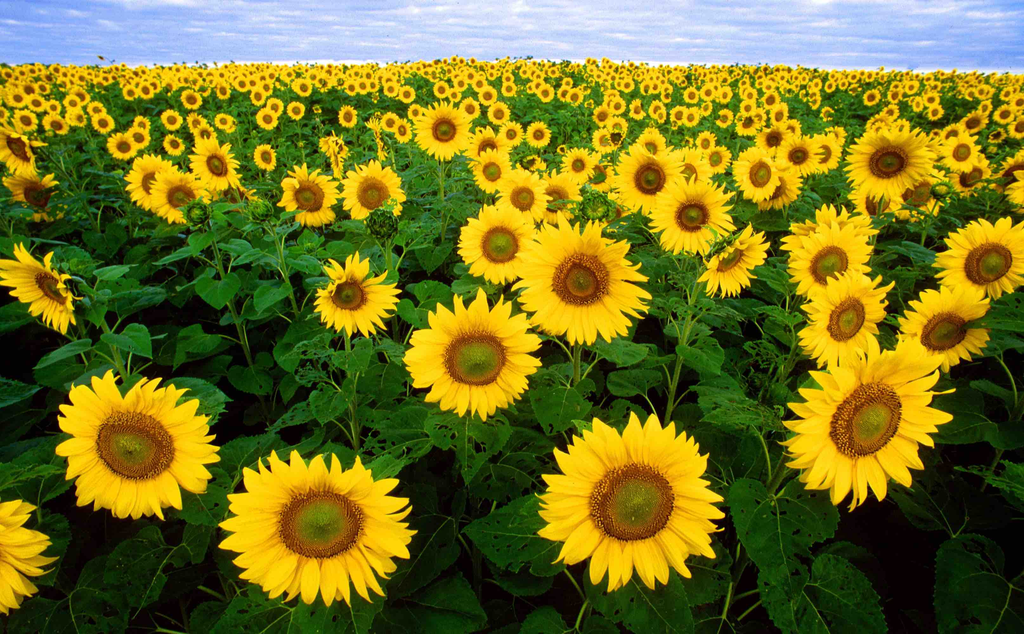

[Larry Hodgson](https://laidbackgardener.blog/2017/05/08/when-sunflowers-kill/)

## Anteriormente em LGN0215

$$p^2 + 2pq + q^2 = 1$$

Em uma população panmítica, cuja reprodução se dá por acasalamento ao acaso (sem autofecundações ou cruzamentos preferenciais), e sob ausência de **migração**, **mutação**, **deriva genética** e **seleção**, as frequências alélicas e genotípicas se mantêm constantes ao longo das gerações, e diz-se que a população encontra-se em equilíbrio.

## Anteriormente em LGN0215

Segundo o Equilíbrio de Wright, as frequências alélicas não mudam através das gerações, ainda que $F \neq 0$, supondo que se trata de uma população grande e sob ausência de processos dispersivos e sistemáticos de modificação de frequências alélicas

| Genótipo | Frequências genotípicas esperadas |
| --- | --- |
| $AA$ | $D = p^2 \color{red}{+ Fpq}$ |
| $Aa$ | $H = 2pq \times \color{red}{(1-F)}$ |
| $aa$ | $R = q^2 \color{red}{+ Fpq}$ |

$$F = \frac{4DR - H^2}{4DR - H^2 + 2H}$$

$$F_n = \frac{1}{2}(1+F_{n-1})$$

## Conteúdo de hoje

1. Processos dispersivos
   - Deriva genética
2. Processos sistemáticos
   - Migração
   - Mutação
   - Seleção

# Processos dispersivos: deriva genética

## Deriva genética

**Para guardar no coração**

Fuga do pressuposto “população infinitamente grande” do EHW. A deriva é representada pela flutuação em torno das frequências alélicas em equílibrio devido à erros de amostragem e/ou eventos aleatórios, uma vez que grande parte das populações reais são finitas. Ela pode levar à fixação de alelos.

- A população é um reservatório de alelos
- Os alelos são transmitidos por meio dos gametas
- A cada geração de acasalamento ao acaso, é realizada uma amostragem dos alelos via formação e transmissão de gametas

## Deriva genética

- População composta por um indivíduo $(N=1)$ heterozigoto (A/a) na geração t<sub>0</sub>
  - Pool gênico: dois alelos (A e a)
  - Frequências alélicas: $p = q = 0,5$
  - Qual a probabilidade de fixação do alelo A, isto é, que as frequências alélicas derivem para $p=1$ e $q=0$? Considere que $N=1$ na geração t<sub>1</sub>

$$\Pr(A) \times \Pr(A) = p^2 = 0,5^2 = 0,25$$

## Deriva genética

$$\Pr(A) \times \Pr(A) = p^2 = 0,5^2 = 0,25$$

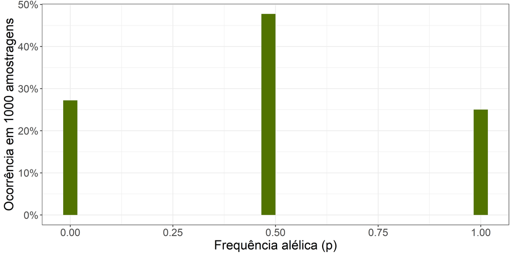

## Deriva genética

- População composta por dois indivíduos $(N = 2)$
  - Qual a probabilidade de fixação de $p$?

$$\underbrace{\Pr(A) \times \Pr(A)}_{\mbox{Indivíduo 1}} \times \underbrace{\Pr(A) \times \Pr(A)}_{\mbox{Indivíduo 2}} = p^4 = 0,25 * 0,25 = 0,0625$$

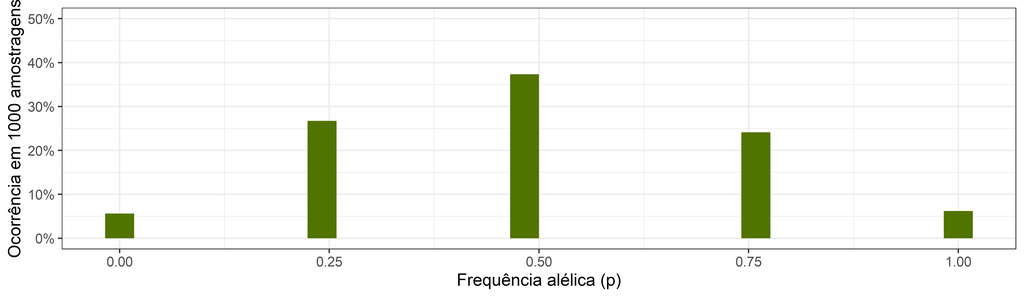

## Deriva genética

A probabilidade de que um alelo sofra deriva para fixação em uma geração futura é igual à sua frequência na geração atual

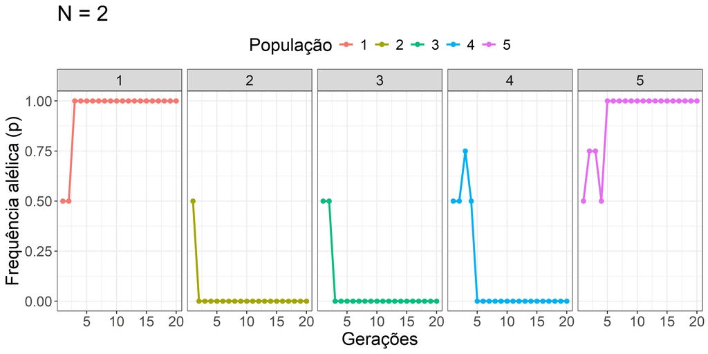

## Deriva genética

- $\Uparrow N \quad \Downarrow$ Efeito da deriva genética
- Chances de fixação de um alelo na geração t: $p^{2N}$

[figure not shown]

## Deriva genética

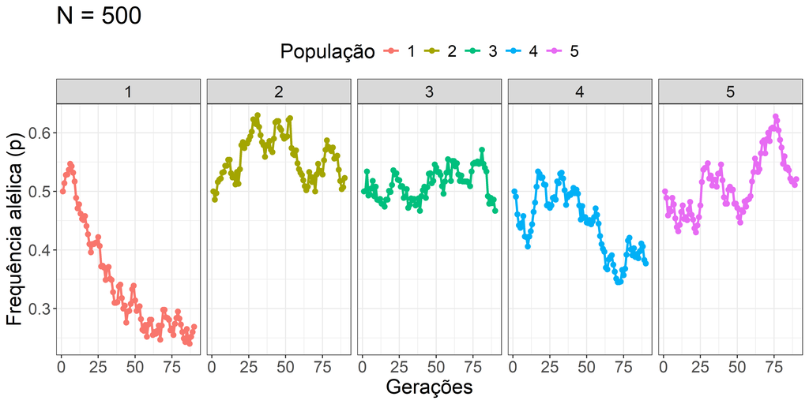

## Deriva genética

**Tamanho efetivo populacional $\left(N_e\right)$**

O tamanho efetivo populacional refere-se ao tamanho que uma população panmítica em equilíbrio deveria ter para sofrer os efeitos da deriva genética. Está relacionado à inúmero fatores, tais como a quantidade de indivíduos aptos para acasalar, proporção entre machos e fêmeas, número de proles por família, a diversidade genética da população, etc.

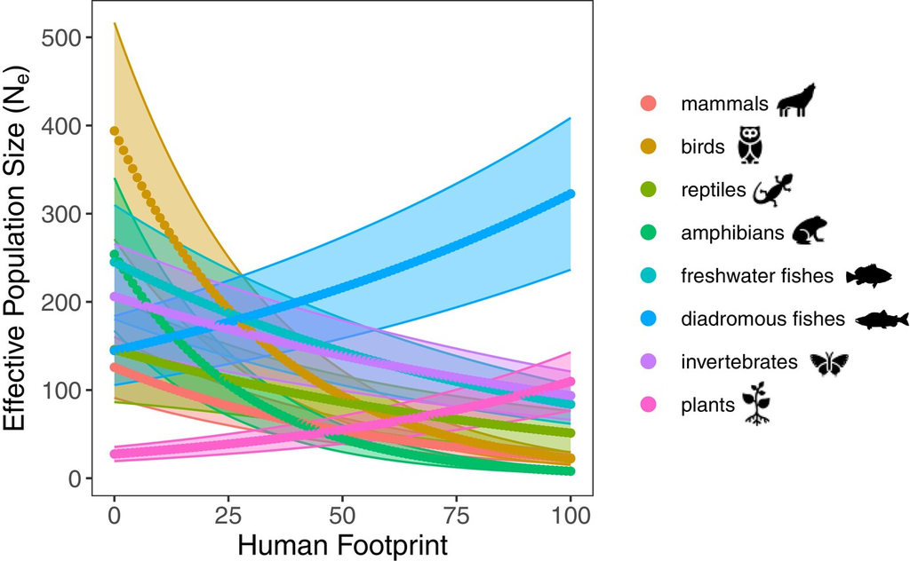

[Clarke et al. (2024)](https://onlinelibrary.wiley.com/doi/10.1111/mec.17353?utm_source=researchgate)

## Deriva genética

- Efeito gargalo (*bottleneck*)

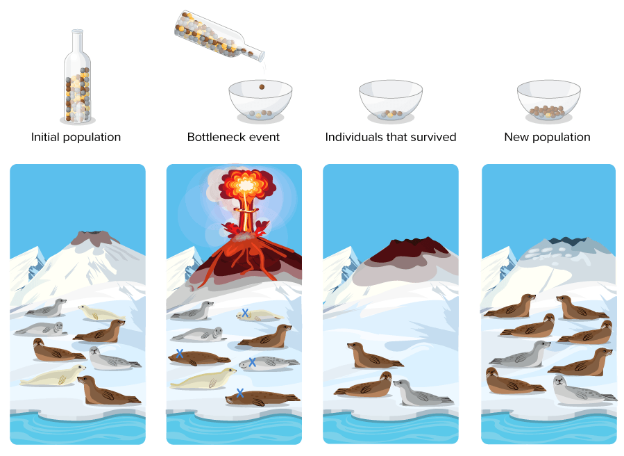

[CK-12 Foundation](https://www.ck12.org/biology/forces-of-evolution-1501903166.77/lesson/Forces-of-Evolution-BIO/)

## Deriva genética

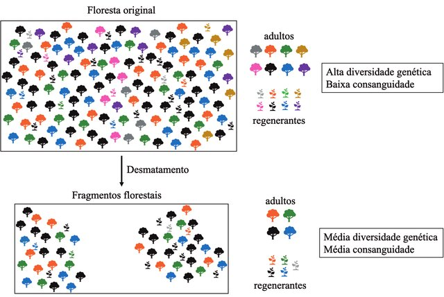

[Martins et al. (2023)](https://www.researchgate.net/publication/372787259_Conservacao_genetica_e_sua_importancia)

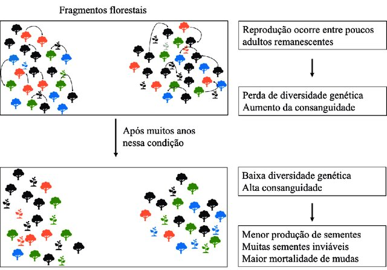

[Martins et al. (2023)](https://www.researchgate.net/publication/372787259_Conservacao_genetica_e_sua_importancia)

## Deriva genética

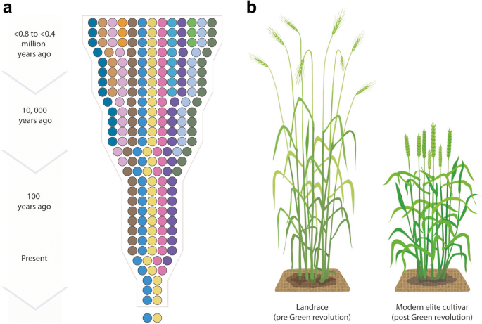

[Voss-Fels et al. (2019)](https://bmcbiol.biomedcentral.com/articles/10.1186/s12915-019-0638-4)

## Deriva genética

- Efeito do fundador

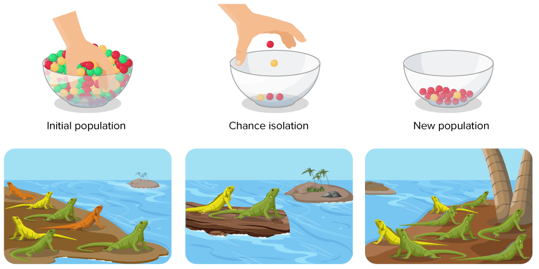

[CK-12 Foundation](https://www.ck12.org/biology/forces-of-evolution-1501903166.77/lesson/Forces-of-Evolution-BIO/)

# Processos sistemáticos: mutação

## Mutação

Mutações são mecanismos aleatórios geradores de variação genética. “A mutação gera novas cartas, a recombinação as embaralha e distribui”

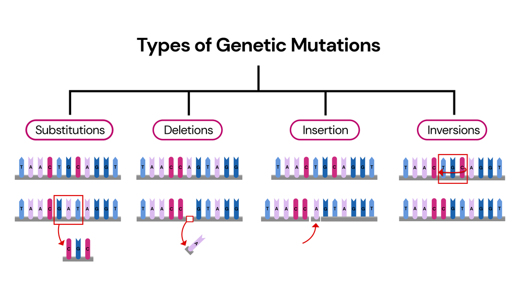

[XCODE](https://www.xcode.life/genetics/what-is-the-ultimate-source-of-genetic-variation/)

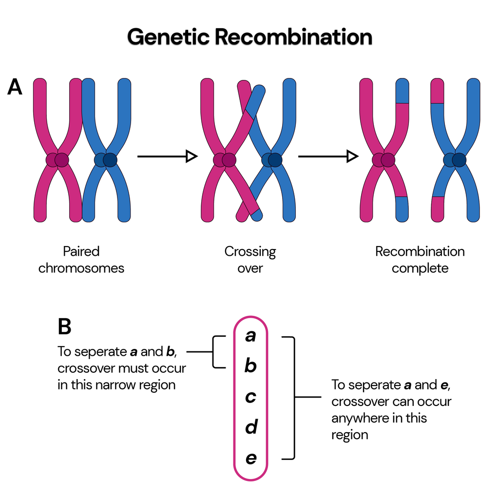

[XCODE](https://www.xcode.life/genetics/what-is-the-ultimate-source-of-genetic-variation/)

## Mutação

- Mutações podem alterar a frequência alélica de uma população
- Alelos $G^1$ e $G^2$

$$N = 25 \begin{cases}
n_{G^1} = 45 \to p=\frac{45}{2\times 25} = 0,9 \\
n_{G^2} = 5 \to q=\frac{5}{2\times 25} = 0,1
\end{cases}$$

$$\begin{gather}
G^1 \to G^2 \\
N = 25 \begin{cases}
n_{G^1} = 44 \to p=\frac{44}{2\times 25} = 0,88 \\
n_{G^2} = 6 \to q=\frac{6}{2\times 25} = 0,12
\end{cases}
\end{gather}$$

## Mutação

- Processo que acontece através de gerações, à uma taxa $\mu$

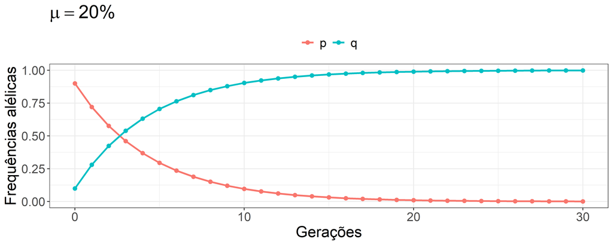

- Quanto menor $p$, menor a quantidade de alelos aptos para mutacionar

## Mutação

- A mutação reversa também é possível, à uma taxa $v$

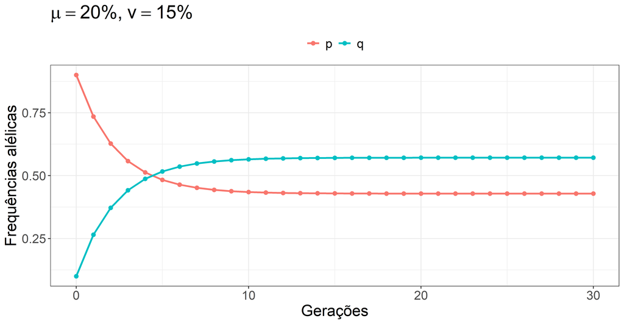

## Mutação

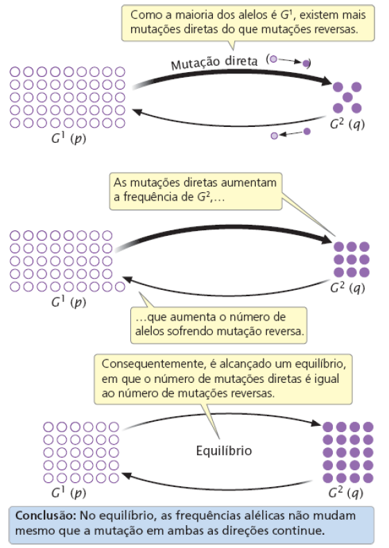

Pierce (2016)

| Organismo | Taxa de mutação (SNP) |
| --- | --- |
| *Arabidopsis* | $7 \times 10^{-9}$ |
| Milho | $3 \times 10^{-8}$ |
| *E. coli* | $5 \times 10^{-10}$ |
| *Drosophila* | $4 \times 10^{-9}$ |
| Camundongo | $4 \times 10^{-9}$ |
| Ser humano | $3 \times 10^{-8}$ |

## Mutação

Cães de Chernobyl

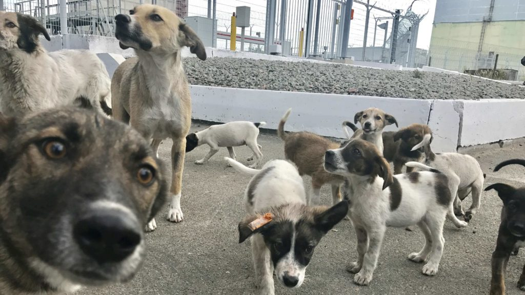

[Jemima Webber](https://www.livekindly.com/how-this-charity-saving-100s-chernobyls-stray-dogs/)

## Mutação

- Mutação nova: alelo $G^3$
- Frequência do $G^3 = r = \frac{1}{2N}$
- Probabilidade de perda da mutação >>> Probabilidade fixação da mutação
  - $1-\frac{1}{2N}$

[figure not shown]

# Processos sistemáticos: migração

## Migração

- Fluxo gênico: movimentação de indivíduos (ou gametas) entre populações
- Introduz nova variação em uma população
  - Aumento da variação genética dentro de uma população
  - Processos que introduzem variação: mutação e migração
- Evita que populações se tornem geneticamente diferentes umas das outras

## Migração

[figure not shown]

[Science Facts](https://www.sciencefacts.net/gene-flow.html)

## Migração

A migração depende da quantidade de indivíduos migrantes e da diferença entre as frequências alélicas das duas (sub)populações

$$q^\prime_{II} = q_I(m) + q_{II} (1-m)$$

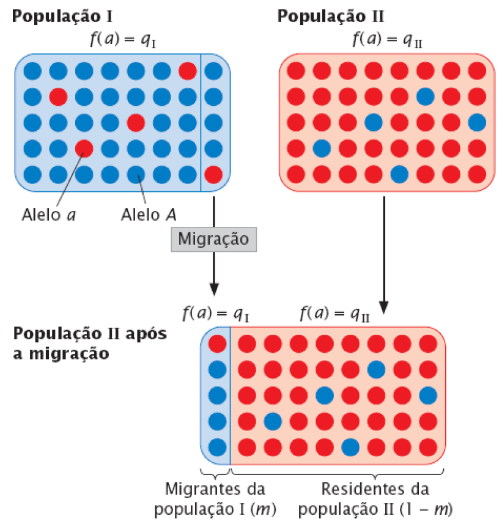

Pierce (2016)

## Migração

Mantendo todos os fatores constantes e assumindo migração unidirecional:

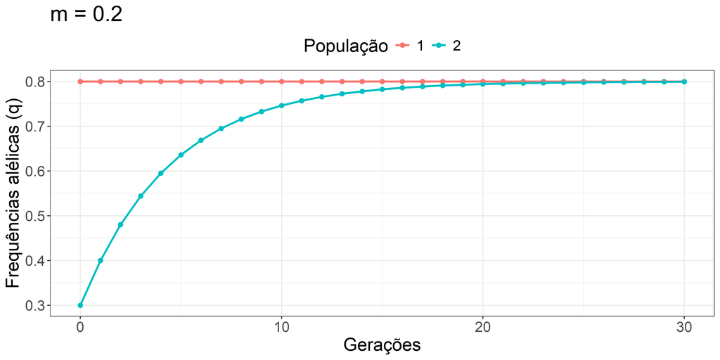

## Migração

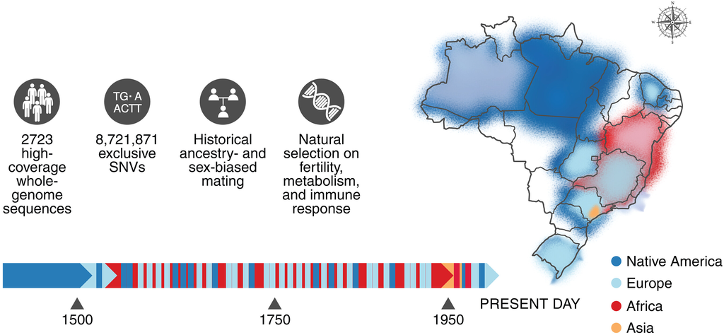

[Nunes et al. (2025)](https://www.science.org/doi/10.1126/science.adl3564)

## Migração

Contaminação de pólen em populações melhoradas

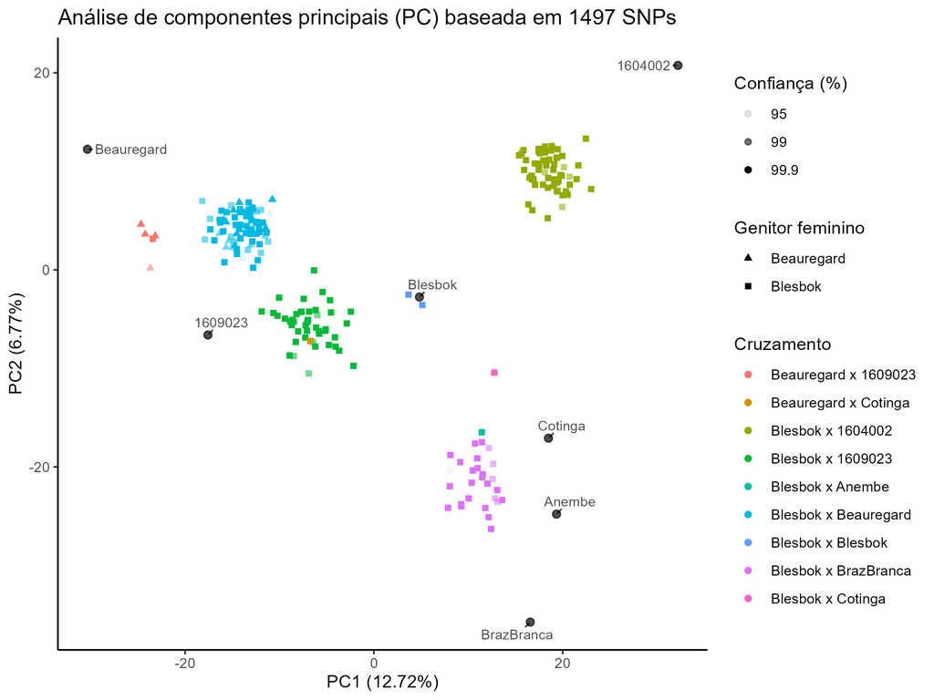

Baptista et al. (2025)

## Migração

Fluxo transgênico

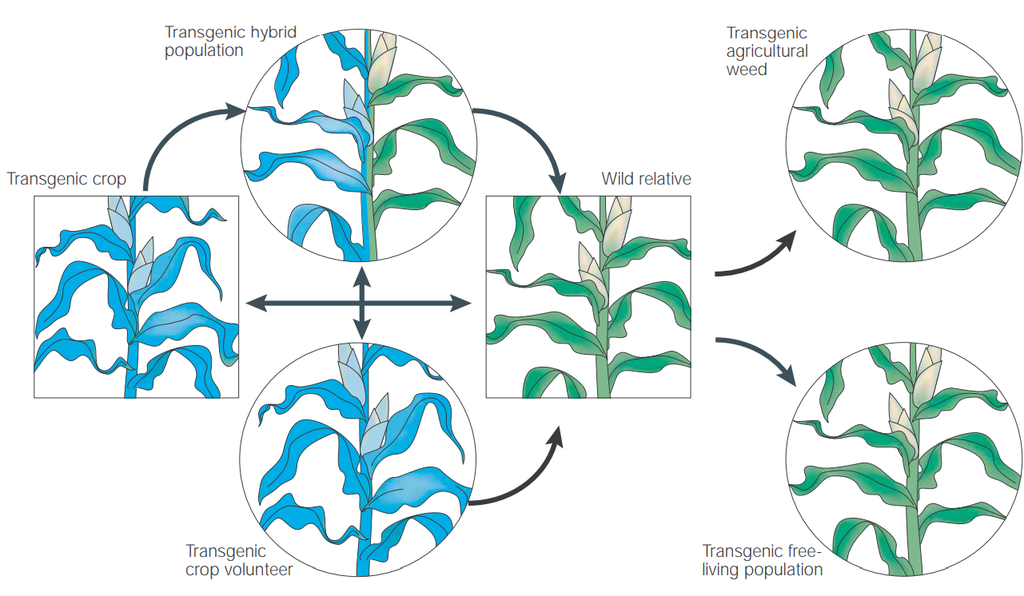

[Stewart et al. (2003)](https://www.nature.com/articles/nrg1179)

# Processos sistemáticos: seleção

## Seleção

- Reprodução diferencial de indivíduos
- Indivíduos mais adaptados deixam mais descendentes: *fitness*
- Natural ou artificial
- Força motriz da **evolução** e principal ferramenta do **melhoramento**

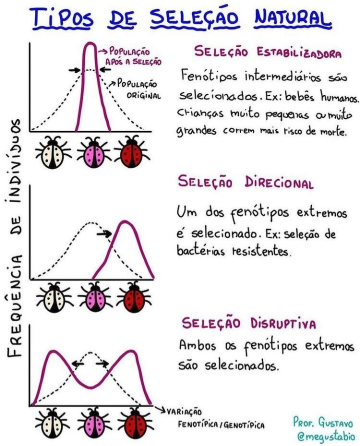

Gustavo Schmidt

## Seleção

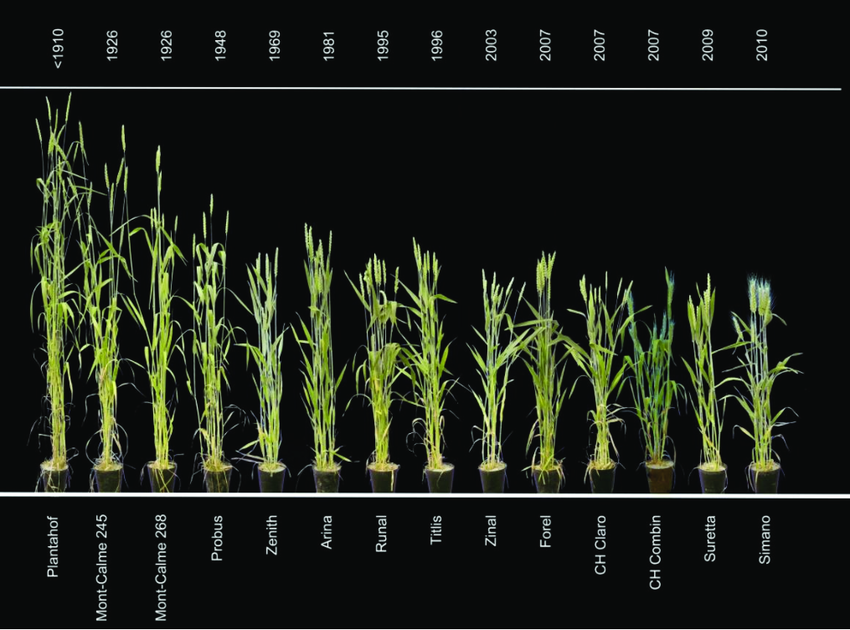

[Friedli et al. (2019)](https://link.springer.com/article/10.1007/s10681-019-2404-7)

## Seleção

- **Fitness**: Valor adaptativo ou valor seletivo
- Sucesso reprodutivo:
  - Probabilidade de sobrevivência até a idade reprodutiva
  - Nº médio de descendentes do indivíduo
- Desconhecido a priori em populações naturais
- Arbitrário em populações de melhoramento
- Fitness absoluto $(W) \to$ tamanho da descendência de um genótipo
- Fitness relativo $(w) \to$ fitness de um genótipo em relação àquele de maior descedência

## Seleção

| Genótipo | Frequência | $W$ | $w$ |
| --- | --- | --- | --- |
| AA | $p^2$ | $10$ | $\frac{10}{10} = 1$ |
| Aa | $2pq$ | $10$ | $\frac{10}{10} = 1$ |
| aa | $q^2$ | $5$ | $\frac{5}{10} = 0,5$ |

**Para guardar no coração: relação entre fitness e seleção**

Se a diferença entre o fitness dos indivíduos está relacionada com a presença ou ausência de um determinado alelo, então a seleção está atuando sobre esse alelo

## Seleção

**Coeficiente de seleção $(s = 1 - w)$**

Redução proporcional da contribuição de gametas para a próxima geração por parte do genótipo não-selecionado comparado ao “favorável”

| Genótipo | Frequência | $w$ | $s = 1-w$ |
| --- | --- | --- | --- |
| AA | $p^2$ | $1$ | $0$ |
| Aa | $2pq$ | $1$ | $0$ |
| aa | $q^2$ | $0,5$ | $0,5$ |

## Seleção

- A seleção impede que todos os genótipos contribuam igualmente com alelos para a próxima geração, causando a fuga do equilíbrio

| Genótipo | Frequência | $w$ | $s = 1-w$ | Contribuição |
| --- | --- | --- | --- | --- |
| AA | $p^2$ | $1$ | $0$ | $p^2 \times 1$ |
| Aa | $2pq$ | $1$ | $0$ | $2pq \times 1$ |
| aa | $q^2$ | $0,5$ | $0,5$ | $q^2 \times 0,5$ |

## Seleção

- Note que a soma da coluna “Contribuição” não soma 1
- Exemplo:

| Genótipo | Frequência | $w$ | $s = 1-w$ | Contribuição |
| --- | --- | --- | --- | --- |
| AA | $0,01$ | $1$ | $0$ | $0,01 \times 1 = 0,01$ |
| Aa | $0,18$ | $1$ | $0$ | $0,18 \times 1 = 0,18$ |
| aa | $0,81$ | $0,5$ | $0,5$ | $0,81 \times 0,5 = 0,405$ |

## Seleção

- Solução: dividir pela soma das contribuições, obtendo a frequência genotípica pós-seleção

| Genótipo | Frequência | $w$ | $s = 1-w$ | Frequência pós-seleção |
| --- | --- | --- | --- | --- |
| AA | $0,01$ | $1$ | $0$ | $\frac{0,01}{0,595} = 0,02$ |
| Aa | $0,18$ | $1$ | $0$ | $\frac{0,18}{0,595}= 0,30$ |
| aa | $0,81$ | $0,5$ | $0,5$ | $\frac{0,405}{0,595}= 0,68$ |

## Seleção

- Frequências alélicas pré-seleção:

$$p_0 = 0,01+\frac{1}{2}\times 0,18 = 0,1$$

$$q_0 = 0,81+\frac{1}{2}\times 0,18 = 0,9$$

- Novas frequências alélicas na população pós-seleção:

$$p_1 = 0,02+\frac{1}{2}\times 0,3 = 0,17$$

$$q_1= 0,68+\frac{1}{2}\times 0,3 = 0,83$$

- Aumento de 7% do alelo dominante

## Seleção

- A seleção pode ocorrer contra (ou a favor) de cada alelo
- No exemplo: seleção contra o recessivo
- Método direto de obtenção das novas frequências alélicas:

$$q_1 = \frac{q_0 - sq_0^2}{1-sq_0^2}$$

$$q^\prime = \frac{0,9 - 0,5 \times 0,9^2}{1-0,5 \times 0,9^2} = 0,83$$

## Seleção

- A fixação de alelos via seleção torna-se mais difícil à medida que as diferenças entre as frequências alélicas aumenta

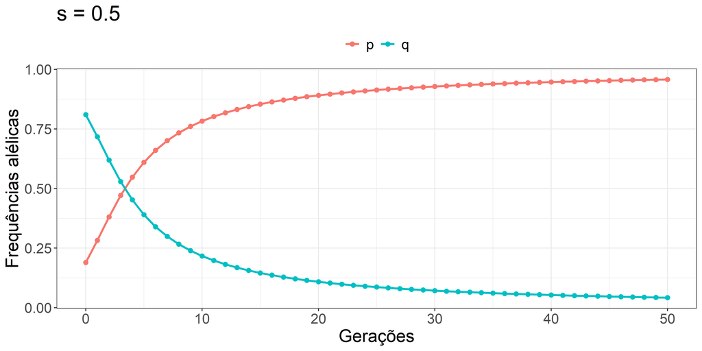

# Apanhado geral

## Vimos hoje

A deriva é representada pela flutuação em torno das frequências alélicas em equílibrio devido à erros de amostragem e/ou eventos aleatórios, fatores ligados à finitude das populações.

[figure not shown]

## Vimos hoje

Mutações são mecanismos aleatórios geradores de variação genética. A mutação de uma forma alélica para outra, ou a formação de uma nova forma alélica, altera as frequências alélicas, tirando a população do equilíbrio. É um evento raríssimo.

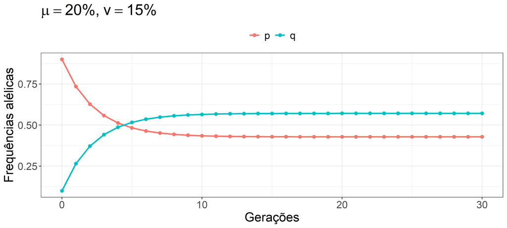

## Vimos hoje

O fluxo gênico (migração) também é um mecanismo capaz de gerar variabilidade em uma população. Ele evita que populações se tornem geneticamente diferentes umas das outras

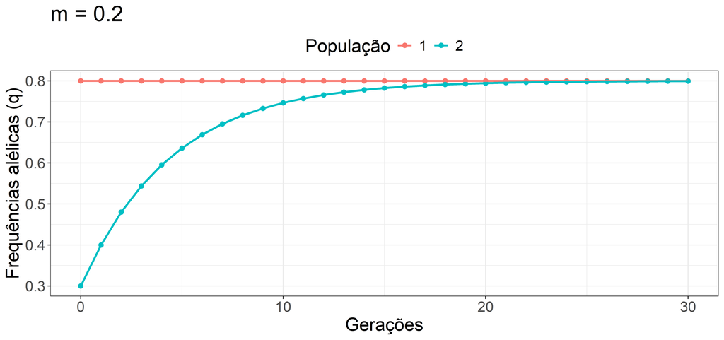